# assignment 1

Author

Haoyu

## Step 1

```r
library(tidyverse)
library(data.table)
library(ggplot2)
data_2022 <- data.table::fread("2022_pm2.5.csv")
data_2002 <- data.table::fread("2002_pm2.5.csv")
dim(data_2002)
```

```
[1] 15976    22
```

```r
dim(data_2022)
```

```
[1] 59756    22
```

```r
head(data_2002)
```

```
         Date Source  Site ID   POC Daily Mean PM2.5 Concentration    Units
       <char> <char>    <int> <int>                          <num>   <char>
1: 01/05/2002    AQS 60010007     1                           25.1 ug/m3 LC
2: 01/06/2002    AQS 60010007     1                           31.6 ug/m3 LC
3: 01/08/2002    AQS 60010007     1                           21.4 ug/m3 LC
4: 01/11/2002    AQS 60010007     1                           25.9 ug/m3 LC
5: 01/14/2002    AQS 60010007     1                           34.5 ug/m3 LC
6: 01/17/2002    AQS 60010007     1                           41.0 ug/m3 LC
   Daily AQI Value Local Site Name Daily Obs Count Percent Complete
             <int>          <char>           <int>            <num>
1:              81       Livermore               1              100
2:              93       Livermore               1              100
3:              74       Livermore               1              100
4:              82       Livermore               1              100
5:              98       Livermore               1              100
```

[output cut: 33 more lines]

```r
head(data_2022)
```

```
         Date Source  Site ID   POC Daily Mean PM2.5 Concentration    Units
       <char> <char>    <int> <int>                          <num>   <char>
1: 01/01/2022    AQS 60010007     3                           12.7 ug/m3 LC
2: 01/02/2022    AQS 60010007     3                           13.9 ug/m3 LC
3: 01/03/2022    AQS 60010007     3                            7.1 ug/m3 LC
4: 01/04/2022    AQS 60010007     3                            3.7 ug/m3 LC
5: 01/05/2022    AQS 60010007     3                            4.2 ug/m3 LC
6: 01/06/2022    AQS 60010007     3                            3.8 ug/m3 LC
   Daily AQI Value Local Site Name Daily Obs Count Percent Complete
             <int>          <char>           <int>            <num>
1:              58       Livermore               1              100
2:              60       Livermore               1              100
3:              39       Livermore               1              100
4:              21       Livermore               1              100
5:              23       Livermore               1              100
```

[output cut: 33 more lines]

```r
tail(data_2002)
```

```
         Date Source  Site ID   POC Daily Mean PM2.5 Concentration    Units
       <char> <char>    <int> <int>                          <num>   <char>
1: 12/10/2002    AQS 61131003     1                             15 ug/m3 LC
2: 12/13/2002    AQS 61131003     1                             15 ug/m3 LC
3: 12/22/2002    AQS 61131003     1                              1 ug/m3 LC
4: 12/25/2002    AQS 61131003     1                             23 ug/m3 LC
5: 12/28/2002    AQS 61131003     1                              5 ug/m3 LC
6: 12/31/2002    AQS 61131003     1                              6 ug/m3 LC
   Daily AQI Value      Local Site Name Daily Obs Count Percent Complete
             <int>               <char>           <int>            <num>
1:              62 Woodland-Gibson Road               1              100
2:              62 Woodland-Gibson Road               1              100
3:               6 Woodland-Gibson Road               1              100
4:              77 Woodland-Gibson Road               1              100
5:              28 Woodland-Gibson Road               1              100
```

[output cut: 33 more lines]

```r
tail(data_2022)
```

```
         Date Source  Site ID   POC Daily Mean PM2.5 Concentration    Units
       <char> <char>    <int> <int>                          <num>   <char>
1: 12/01/2022    AQS 61131003     1                            3.4 ug/m3 LC
2: 12/07/2022    AQS 61131003     1                            3.8 ug/m3 LC
3: 12/13/2022    AQS 61131003     1                            6.0 ug/m3 LC
4: 12/19/2022    AQS 61131003     1                           34.8 ug/m3 LC
5: 12/25/2022    AQS 61131003     1                           23.2 ug/m3 LC
6: 12/31/2022    AQS 61131003     1                            1.0 ug/m3 LC
   Daily AQI Value      Local Site Name Daily Obs Count Percent Complete
             <int>               <char>           <int>            <num>
1:              19 Woodland-Gibson Road               1              100
2:              21 Woodland-Gibson Road               1              100
3:              33 Woodland-Gibson Road               1              100
4:              99 Woodland-Gibson Road               1              100
5:              77 Woodland-Gibson Road               1              100
```

[output cut: 33 more lines]

```r
summary(data_2002)
```

```
     Date              Source             Site ID              POC
 Length:15976       Length:15976       Min.   :60010007   Min.   :1.000
 Class :character   Class :character   1st Qu.:60290014   1st Qu.:1.000
 Mode  :character   Mode  :character   Median :60590007   Median :1.000
                                       Mean   :60549600   Mean   :1.581
                                       3rd Qu.:60731002   3rd Qu.:1.000
                                       Max.   :61131003   Max.   :6.000

 Daily Mean PM2.5 Concentration    Units           Daily AQI Value
 Min.   :  0.00                 Length:15976       Min.   :  0.00
 1st Qu.:  7.00                 Class :character   1st Qu.: 39.00
 Median : 12.00                 Mode  :character   Median : 56.00
 Mean   : 16.12                                    Mean   : 59.28
 3rd Qu.: 20.50                                    3rd Qu.: 72.00
 Max.   :104.30                                    Max.   :185.00

 Local Site Name    Daily Obs Count Percent Complete AQS Parameter Code
 Length:15976       Min.   :1       Min.   :100      Min.   :88101
 Class :character   1st Qu.:1       1st Qu.:100      1st Qu.:88101
 Mode  :character   Median :1       Median :100      Median :88101
                    Mean   :1       Mean   :100      Mean   :88215
                    3rd Qu.:1       3rd Qu.:100      3rd Qu.:88502
                    Max.   :1       Max.   :100      Max.   :88502

 AQS Parameter Description  Method Code  Method Description   CBSA Code
 Length:15976              Min.   :117   Length:15976       Min.   :12540
 Class :character          1st Qu.:120   Class :character   1st Qu.:23420
 Mode  :character          Median :120   Mode  :character   Median :40140
                           Mean   :297                      Mean   :33270
                           3rd Qu.:707                      3rd Qu.:41740
                           Max.   :810                      Max.   :49700
                                                            NA's   :929
  CBSA Name         State FIPS Code    State           County FIPS Code
 Length:15976       Min.   :6       Length:15976       Min.   :  1.00
 Class :character   1st Qu.:6       Class :character   1st Qu.: 29.00
 Mode  :character   Median :6       Mode  :character   Median : 59.00
                    Mean   :6                          Mean   : 54.78
                    3rd Qu.:6                          3rd Qu.: 73.00
                    Max.   :6                          Max.   :113.00

    County          Site Latitude   Site Longitude
 Length:15976       Min.   :32.63   Min.   :-124.2
 Class :character   1st Qu.:34.07   1st Qu.:-121.4
 Mode  :character   Median :35.36   Median :-119.1
                    Mean   :36.00   Mean   :-119.4
                    3rd Qu.:37.77   3rd Qu.:-117.9
                    Max.   :41.71   Max.   :-115.5
```

```r
summary(data_2022)
```

```
     Date              Source             Site ID              POC
 Length:59756       Length:59756       Min.   :60010007   Min.   : 1.00
 Class :character   Class :character   1st Qu.:60290019   1st Qu.: 1.00
 Mode  :character   Mode  :character   Median :60631006   Median : 3.00
                                       Mean   :60563315   Mean   : 3.77
                                       3rd Qu.:60731026   3rd Qu.: 3.00
                                       Max.   :61131003   Max.   :24.00

 Daily Mean PM2.5 Concentration    Units           Daily AQI Value
 Min.   : -6.700                Length:59756       Min.   :  0.00
 1st Qu.:  4.100                Class :character   1st Qu.: 23.00
 Median :  6.800                Mode  :character   Median : 38.00
 Mean   :  8.429                                   Mean   : 39.28
 3rd Qu.: 10.700                                   3rd Qu.: 54.00
 Max.   :302.500                                   Max.   :454.00

 Local Site Name    Daily Obs Count Percent Complete AQS Parameter Code
 Length:59756       Min.   :1       Min.   :100      Min.   :88101
 Class :character   1st Qu.:1       1st Qu.:100      1st Qu.:88101
 Mode  :character   Median :1       Median :100      Median :88101
                    Mean   :1       Mean   :100      Mean   :88192
                    3rd Qu.:1       3rd Qu.:100      3rd Qu.:88101
                    Max.   :1       Max.   :100      Max.   :88502

 AQS Parameter Description  Method Code  Method Description   CBSA Code
 Length:59756              Min.   :143   Length:59756       Min.   :12540
 Class :character          1st Qu.:170   Class :character   1st Qu.:31080
 Mode  :character          Median :170   Mode  :character   Median :40140
                           Mean   :336                      Mean   :34957
                           3rd Qu.:707                      3rd Qu.:41860
                           Max.   :810                      Max.   :49700
                                                            NA's   :4567
  CBSA Name         State FIPS Code    State           County FIPS Code
 Length:59756       Min.   :6       Length:59756       Min.   :  1.00
 Class :character   1st Qu.:6       Class :character   1st Qu.: 29.00
 Mode  :character   Median :6       Mode  :character   Median : 63.00
                    Mean   :6                          Mean   : 56.19
                    3rd Qu.:6                          3rd Qu.: 73.00
                    Max.   :6                          Max.   :113.00

    County          Site Latitude   Site Longitude
 Length:59756       Min.   :32.58   Min.   :-124.2
 Class :character   1st Qu.:34.07   1st Qu.:-121.4
 Mode  :character   Median :36.49   Median :-119.6
                    Mean   :36.24   Mean   :-119.6
                    3rd Qu.:37.96   3rd Qu.:-117.9
                    Max.   :41.76   Max.   :-115.5
```

```r
names(data_2002)
```

```
 [1] "Date"                           "Source"
 [3] "Site ID"                        "POC"
 [5] "Daily Mean PM2.5 Concentration" "Units"
 [7] "Daily AQI Value"                "Local Site Name"
 [9] "Daily Obs Count"                "Percent Complete"
[11] "AQS Parameter Code"             "AQS Parameter Description"
[13] "Method Code"                    "Method Description"
[15] "CBSA Code"                      "CBSA Name"
[17] "State FIPS Code"                "State"
[19] "County FIPS Code"               "County"
[21] "Site Latitude"                  "Site Longitude"
```

```r
names(data_2022)
```

```
 [1] "Date"                           "Source"
 [3] "Site ID"                        "POC"
 [5] "Daily Mean PM2.5 Concentration" "Units"
 [7] "Daily AQI Value"                "Local Site Name"
 [9] "Daily Obs Count"                "Percent Complete"
[11] "AQS Parameter Code"             "AQS Parameter Description"
[13] "Method Code"                    "Method Description"
[15] "CBSA Code"                      "CBSA Name"
[17] "State FIPS Code"                "State"
[19] "County FIPS Code"               "County"
[21] "Site Latitude"                  "Site Longitude"
```

```r
sum(is.na(data_2002$State))
```

```
[1] 0
```

```r
sum(is.na(data_2022$State))
```

```
[1] 0
```

It can be seen from the statistical data that these two data sets mainly provide detailed statistics on the pm2.5 pollutant content in California, including different regions. There are missing values in “CBSA Name”.

## Step 2

```r
data_2002 <- data_2002 %>%
  mutate(Year = 2002)
data_2022 <- data_2022 %>%
  mutate(Year = 2022)
combined_data <- rbind(data_2002, data_2022)
setnames(combined_data, old = "Daily Mean PM2.5 Concentration", new = "PM2.5")
setnames(combined_data, old = "Site Latitude", new = "Lat")
setnames(combined_data, old = "Site Longitude", new = "Lon")
setnames(combined_data, old = "Local Site Name", new = "Site")
setnames(combined_data, old = "CBSA Name", new = "City")
```

## Step 3

```r
library(leaflet)
Sites <- combined_data %>%
  select(Site, Lon, Lat, Year) %>%
  distinct()


color_palette <- colorFactor(palette = c("red","blue"),
                             levels = unique(Sites$Year))
leaflet(Sites) %>%
  addTiles() %>%
  addCircleMarkers(
    ~Lon, ~Lat,
    color = ~color_palette(Year),
    radius = 5,
    stroke = FALSE,
    fillOpacity = 0.5,
    popup = ~Site,
    label = ~paste("Year:", Year, "Site:", Site)) %>%
  addLegend(
    "bottomright",
    pal = colorFactor(palette = c("red", "blue"),
                      levels = unique(Sites$Year)),
    values = unique(Sites$Year),
    title = "Year",
    opacity = 1
  )
```

[interactive chart not shown]

These stations are mainly concentrated in Los Angeles and San Francisco. I guess it is because these two places are economically developed large cities in California with large populations and a great impact of air pollution, so there are more stations for easy observation.

## Step 4

```r
combined_data %>%
  summarise(
    missing_values = sum(is.na(PM2.5)),
    min_PM2.5 = min(PM2.5, na.rm = TRUE),
    max_PM2.5 = max(PM2.5, na.rm = TRUE),
    outliers = sum(PM2.5 < 0 | PM2.5 > 500)
  )
```

```
  missing_values min_PM2.5 max_PM2.5 outliers
1              0      -6.7     302.5      215
```

```r
combined_data <- combined_data %>%
  filter(PM2.5 >= 0)
```

From the statistical data, some PM2.5 values are less than 0. This is unreasonable and needs to be deleted.

## Step 5

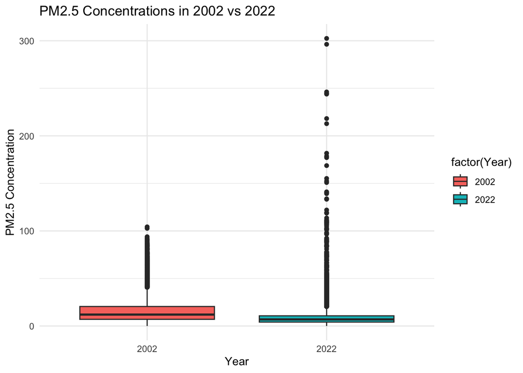

```r
# state
ggplot(combined_data, aes(x = factor(Year), y = PM2.5, fill = factor(Year))) +
  geom_boxplot() +
  labs(title = "PM2.5 Concentrations in 2002 vs 2022",
       x = "Year",
       y = "PM2.5 Concentration") +
  theme_minimal()
```

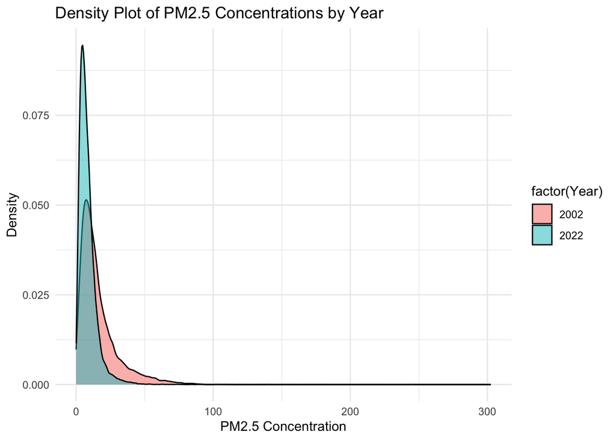

```r
ggplot(combined_data, aes(x = PM2.5, fill = factor(Year))) +
  geom_density(alpha = 0.5) +
  labs(title = "Density Plot of PM2.5 Concentrations by Year", x = "PM2.5 Concentration", y = "Density") +
  theme_minimal()
```

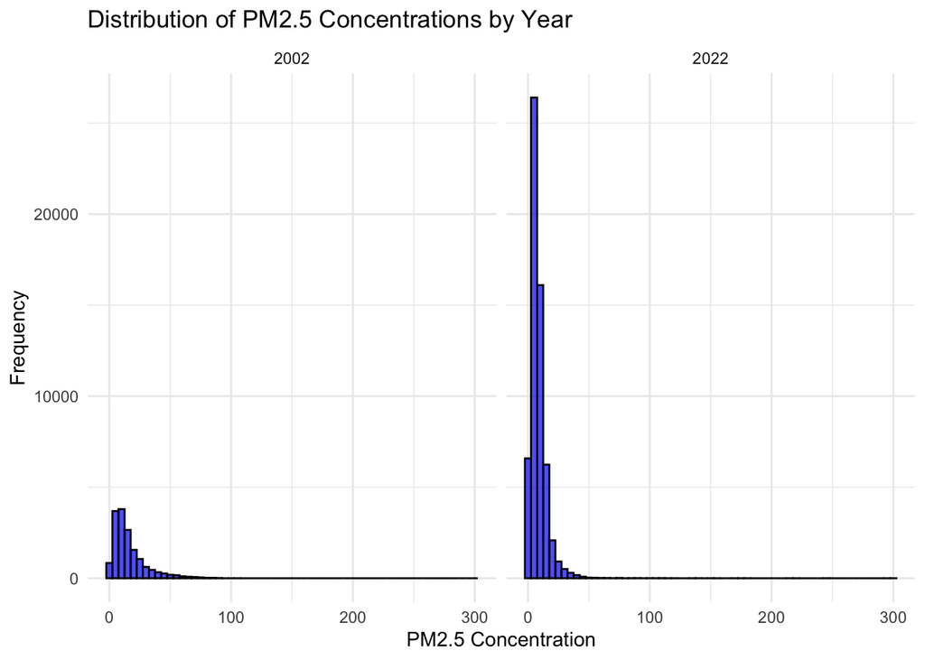

```r
ggplot(combined_data, aes(x = PM2.5)) +
  geom_histogram(binwidth = 5, fill = "blue", color = "black", alpha = 0.7) +
  labs(title = "Distribution of PM2.5 Concentrations by Year",
       x = "PM2.5 Concentration",
       y = "Frequency") +
  facet_wrap(~ Year) +
  theme_minimal()
```

From the perspective of California, the pm2.5 content in 2022 is overall lower than that in 2002, but the maximum value is larger than that in 2002.

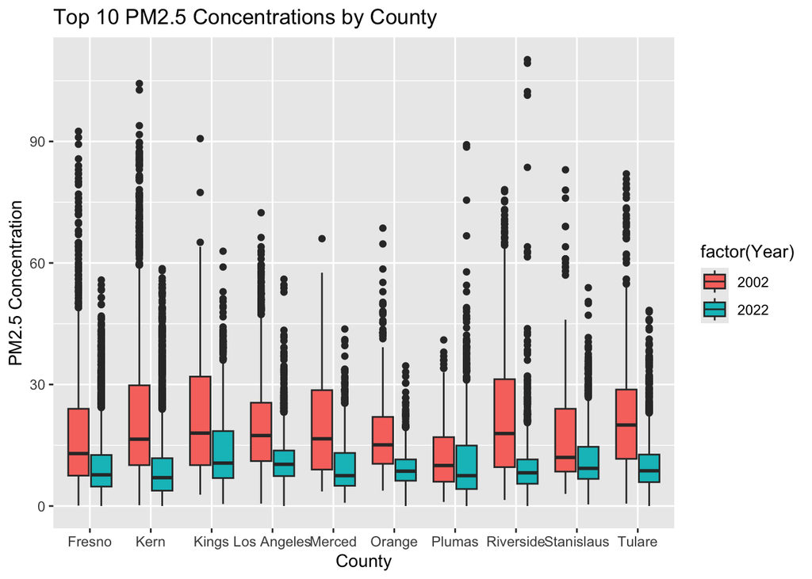

```r
# county
county_summary <- combined_data %>%
  group_by(County) %>%
  summarise(mean_PM2.5 = mean(PM2.5, na.rm = TRUE)) %>%
  arrange(desc(mean_PM2.5))

top_counties <- county_summary %>%
  top_n(10, mean_PM2.5)

ggplot(combined_data %>% filter(County %in% top_counties$County), aes(x = County, y = PM2.5, fill = factor(Year))) +
  geom_boxplot() +
  labs(title = "Top 10 PM2.5 Concentrations by County",
       x = "County",
       y = "PM2.5 Concentration")
```

[figure not shown]

```r
# LA
la_data <- combined_data %>%
  filter(City == "Los Angeles-Long Beach-Anaheim, CA")

ggplot(la_data, aes(x = Date, y = PM2.5)) +
  geom_line(color = "blue") +
  labs(title = "PM2.5 Concentration Over Time in Los Angeles",
       x = "Date",
       y = "PM2.5 Concentration") +
  theme_minimal()
```

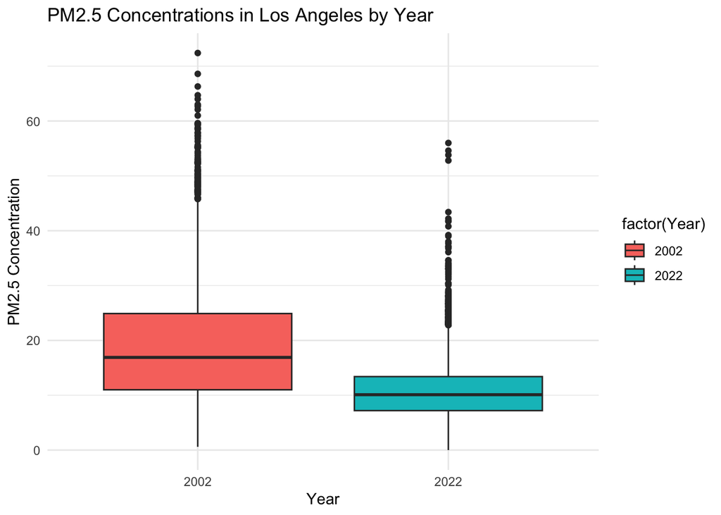

```r
ggplot(la_data, aes(x = factor(Year), y = PM2.5, fill = factor(Year))) +
  geom_boxplot() +
  labs(title = "PM2.5 Concentrations in Los Angeles by Year",
       x = "Year",
       y = "PM2.5 Concentration") +
  theme_minimal()
```

From the perspective of LA, whether it is the maximum value or overall, the pm2.5 content in 2022 is smaller than that in 2002.